© Bản quyền thuộc về Quantopian Inc.  
© Bản quyền sửa đổi thuộc về AI Cafe¹  
Giấy phép [Creative Commons Attribution 4.0](https://creativecommons.org/licenses/by/4.0/legalcode).  
[Khuyến cáo](https://aicafe.one/khuyen-cao/)

# Giá trị rủi ro danh mục đầu tư và Giá trị rủi ro có điều kiện

By Jonathan Larkin and Delaney Granizo-Mackenzie

Edited by AI Cafe¹

Giá trị rủi ro (VaR) là một khái niệm quan trọng trong quản lý rủi ro danh mục đầu tư. Nó sử dụng phân phối lợi nhuận danh mục đầu tư đã quan sát trong quá khứ để ước tính những khoản lỗ trong tương lai của bạn có thể là gì ở các mức độ xác suất khác nhau. Hãy minh họa khái niệm này qua một ví dụ.

```python
import numpy as np
import pandas as pd

from scipy.stats import norm

import matplotlib.pyplot as plt
```

## Ví dụ Dữ liệu Giả lập

Hãy giả lập một số lợi nhuận của 10 tài sản giả thuyết.

**LƯU Ý**

Chúng ta sử dụng phân phối chuẩn để giả lập các lợi nhuận, trong thực tế, lợi nhuận hầu như không bao giờ tuân theo phân phối chuẩn và thường có hành vi kỳ lạ bao gồm đuôi mập. Chúng ta sẽ thảo luận thêm về điều này sau.

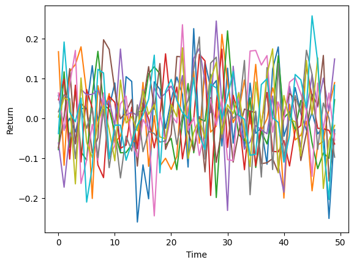

```python
# mu = 0.01, std = 0.10, 1000 bars, 10 assets
mu = 0.01
sigma = 0.10
bars = 1000
num_assets = 10

returns = np.random.normal(mu, sigma, (bars, num_assets))

# Fake asset names
names = ['Asset %s' %i  for i in range(num_assets)]

# Put in a pandas dataframe
returns = pd.DataFrame(returns, columns=names)

# Plot the last 50 bars
plt.plot(returns.head(50))
plt.xlabel('Time')
plt.ylabel('Return');
```

Giá trị tại Rủi ro (VaR) cho mức độ bao phủ $\alpha$ được định nghĩa là số tiền tối đa mà chúng ta có thể kỳ vọng sẽ mất với xác suất $p = 1 - \alpha$. Nói cách khác, trong không quá $100 \times p \%$ số ngày, chúng ta nên kỳ vọng sẽ mất nhiều hơn VaR. Có nhiều cách để ước tính VaR và không có cách nào là hoàn hảo. Thực tế, bạn không nên đặt hoàn toàn niềm tin vào VaR, nó chủ yếu nhằm mục đích giúp bạn có cái nhìn tổng quan về mức độ tổn thất có thể xảy ra trong các kịch bản cực đoan khác nhau và cung cấp thông tin này cho những người chịu trách nhiệm quản lý rủi ro.

VaR cho một mức $\alpha$ cao là một thước đo cho các kết quả tồi tệ nhất. Ví dụ, một người có thể theo dõi VaR với $\alpha = 0.999$ để hiểu cách mà một sự kiện khủng hoảng 1/1000 có thể ảnh hưởng đến họ. Bởi vì các phân phối thực tế có xu hướng phân kỳ và trở nên ít nhất quán hơn khi ta đi sâu vào đuôi, VaR cực đoan nên được tiếp nhận với sự thận trọng.

## Mối quan hệ với Khoảng tin cậy

Đối với những ai quen thuộc với khoảng tin cậy, VaR rất giống với nó. Ý tưởng cố gắng bao phủ một tập hợp các giá trị có thể bằng một khoảng được xác định bởi $\alpha$ tương tự như cách mà VaR cố gắng bao phủ một tập hợp các tổn thất có thể. Đối với những ai không quen thuộc, hãy xem bài giảng về Khoảng tin cậy.

## VaR Lịch Sử (Không Tham Số)

Chúng ta sẽ sử dụng VaR lịch sử, cái nhìn vào phân phối lợi nhuận trước đây và sử dụng nó để tính toán phân vị $p$. Phân vị này là số tiền thua lỗ mà bạn có thể kỳ vọng hợp lý sẽ trải qua với xác suất $p$, giả định rằng lợi nhuận trong tương lai gần giống với lợi nhuận trong quá khứ. Một lần nữa, điều này không hoàn hảo và yêu cầu rằng không có sự thay đổi chế độ mà trong đó phân phối lợi nhuận thay đổi. Ví dụ, nếu khoảng thời gian lịch sử của bạn không bao gồm bất kỳ sự kiện khủng hoảng nào, ước lượng VaR của bạn sẽ thấp hơn nhiều so với thực tế.

Để tính toán VaR lịch sử cho độ bao phủ $\alpha$, chúng ta chỉ cần lấy phân vị $100 \times (1 - \alpha)$ của các lợi nhuận quan sát thấp nhất và nhân nó với tổng giá trị đầu tư của chúng ta.

Bây giờ hãy tính toán VaR của bộ 10 tài sản này. Để làm điều này, chúng ta cần một bộ trọng số danh mục đầu tư. Chúng ta sẽ bắt đầu thật đơn giản.

```python
weights = np.ones((10, 1))
# Normalize
weights = weights / np.sum(weights)
```

```python
def value_at_risk(value_invested, returns, weights, alpha=0.95, lookback_days=520):
    returns = returns.fillna(0.0)
    # Multiply asset returns by weights to get one weighted portfolio return
    portfolio_returns = returns.iloc[-lookback_days:].dot(weights)
    # Compute the correct percentile loss and multiply by value invested
    return np.percentile(portfolio_returns, 100 * (1-alpha)) * value_invested
```

Chúng ta sẽ tính toán VaR cho $\alpha = 0.95$.

```python
value_invested = 1000_000

value_at_risk(value_invested, returns, weights, alpha=0.95)
```

```
np.float64(-44447.79514550677)
```

Giải thích điều này, chúng ta nói rằng trong lịch sử không có hơn $5\%$ số ngày dẫn đến những khoản lỗ cực đoan hơn con số này, hoặc rằng vào mỗi ngày, xác suất bạn bị lỗ nhiều như vậy là dưới $5\%$. Hãy nhớ rằng bất kỳ dự đoán nào như vậy chỉ là một ước lượng.

## VaR Lịch Sử Phân Phối Chuẩn và Phi Tham Số

### Trường Hợp Phân Phối Chuẩn

Một trường hợp đặc biệt của VaR là khi bạn giả định rằng lợi suất tuân theo một phân phối nhất định thay vì ước lượng phi tham số theo lịch sử. Trong trường hợp này, VaR chuẩn sẽ phù hợp với dữ liệu của chúng ta, vì tất cả lợi suất của chúng ta đều được mô phỏng từ một phân phối chuẩn. Chúng ta có thể kiểm tra điều này bằng cách sử dụng Hàm Phân Phối Tích Lũy (CDF) của phân phối chuẩn, bằng cách tổng hợp diện tích dưới đường cong chuẩn để xác định khả năng của những giá trị nhất định. Chúng ta sẽ sử dụng CDF ngược, hay PPF, mà cho một xác suất nhất định sẽ cho chúng ta biết giá trị nào tương ứng với xác suất đó.

Cụ thể, công thức dạng đóng cho VaR Phân Phối Chuẩn là

$$VaR_{\alpha}(x) = \mu - \sigma N^{-1}(\alpha)$$

```python
# Portfolio mean return is unchanged, but std has to be recomputed
# This is because independent variances sum, but std is sqrt of variance
portfolio_std = np.sqrt( np.power(sigma, 2) * num_assets ) / num_assets

# manually
(mu - portfolio_std * norm.ppf(0.95)) * value_invested
```

```
np.float64(-42014.83878755574)
```

Kết quả này đủ gần với ước lượng ở trên. Hãy hình dung trường hợp phân phối chuẩn liên tục. Lưu ý rằng VaR được biểu thị dưới dạng tỷ suất lợi nhuận thay vì tổn thất tuyệt đối. Để có được tổn thất tuyệt đối, chúng ta chỉ cần nhân với giá trị đầu tư.

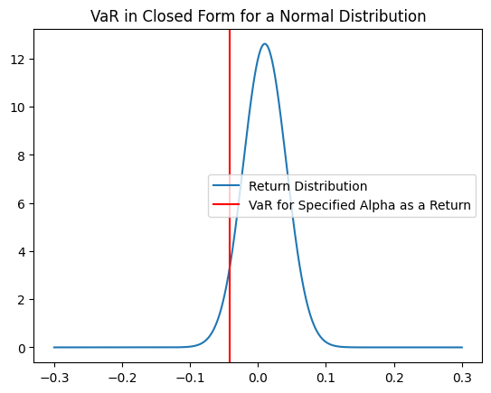

```python
def value_at_risk_N(mu=0, sigma=1.0, alpha=0.95):
    return mu - sigma*norm.ppf(alpha)


x = np.linspace(-3*sigma,3*sigma,1000)
y = norm.pdf(x, loc=mu, scale=portfolio_std)
plt.plot(x,y);
plt.axvline(value_at_risk_N(mu = 0.01, sigma = portfolio_std, alpha=0.95), color='red', linestyle='solid');
plt.legend(['Return Distribution', 'VaR for Specified Alpha as a Return'])
plt.title('VaR in Closed Form for a Normal Distribution');
```

### Trường hợp Lịch sử (Phi tham số)

VaR lịch sử sử dụng dữ liệu lịch sử để vẽ một Hàm mật độ xác suất rời rạc, hoặc biểu đồ histogram, sau đó tìm điểm mà chỉ có $100 \times (1-\alpha)\%$ các điểm nằm dưới mức lợi nhuận đó. Nó trả về mức lợi nhuận đó như là mức lợi nhuận VaR cho mức độ bao phủ $\alpha$.

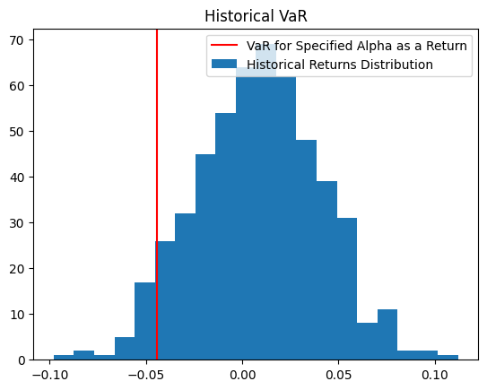

```python
lookback_days = 520
alpha = 0.95

# Multiply asset returns by weights to get one weighted portfolio return
portfolio_returns = returns.fillna(0.0).iloc[-lookback_days:].dot(weights)

portfolio_VaR = value_at_risk(value_invested, returns, weights, alpha=0.95)
# Need to express it as a return rather than absolute loss
portfolio_VaR_return = portfolio_VaR / value_invested

plt.hist(portfolio_returns.values, bins=20)
plt.axvline(portfolio_VaR_return, color='red', linestyle='solid');
plt.legend(['VaR for Specified Alpha as a Return', 'Historical Returns Distribution'])
plt.title('Historical VaR');
```

## Các Phân Phối Cơ Sở Không Phải Lúc Nào Cũng Chuẩn

Trong dữ liệu tài chính thực tế, các phân phối cơ sở hiếm khi là phân phối chuẩn. Đó là lý do tại sao chúng ta ưa thích VaR lịch sử hơn là giả định về một phân phối cơ sở. VaR lịch sử cũng là phi tham số, vì vậy chúng ta không gặp rủi ro khi điều chỉnh tham số phân phối cho một tập dữ liệu nào đó.

### Ví Dụ Dữ Liệu Thực Tế

Chúng tôi sẽ minh họa điều này với một số dữ liệu tài chính thực tế.

```python
# Cài thư viện lấy dữ liệu miễn phí
!curl -fsSLO https://raw.githubusercontent.com/algo-stocks/data/master/data.py
```

```python
from data import get_prices

start = '2023-01-01'
end = '2025-04-30'

tickers = "ACB,BCM,BID,BVH,CTG,FPT,GAS,GVR,HDB,HPG,LPB,MBB,MSN,MWG,PLX,SAB,SHB,SSB,SSI,STB,TCB,TPB,VCB,VHM,VIB,VIC,VJC,VNM,VPB,VRE".split(',')
prices = get_prices(*tickers, start_date=start, end_date=end).ffill()
```

```python
returns = prices.pct_change()
returns = returns - returns.mean(skipna=True) # de-mean the returns
```

Bây giờ chúng ta cần tạo ra một số trọng số.

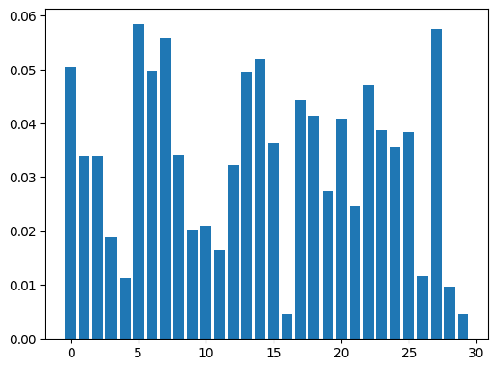

```python
def scale(x):
    return x / np.sum(np.abs(x))

num_stocks = len(prices.columns)
weights = scale(np.random.random(num_stocks))
plt.bar(np.arange(num_stocks), weights);
```

Bây giờ hãy tính toán VaR cho $\alpha = 0.95$. Từ bây giờ, chúng ta sẽ viết điều này là $VaR_{\alpha=0.95}$.

```python
value_at_risk(value_invested, returns, weights, alpha=0.95, lookback_days=520)
```

```
np.float64(-15661.446446896845)
```

Và minh hoạ trên đồ thị

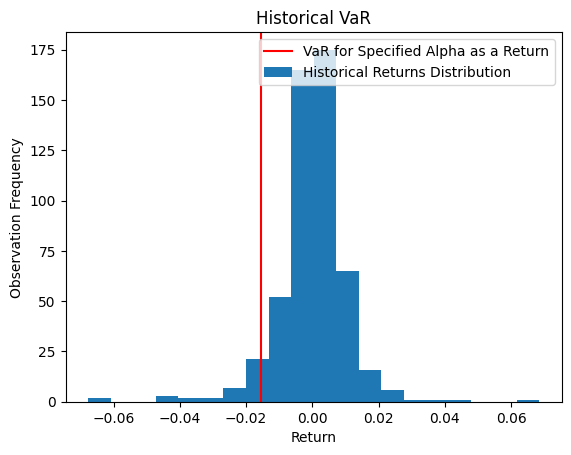

```python
lookback_days = 520
alpha = 0.95

# Multiply asset returns by weights to get one weighted portfolio return
portfolio_returns = returns.fillna(0.0).iloc[-lookback_days:].dot(weights)

portfolio_VaR = value_at_risk(value_invested, returns, weights, alpha=0.95)
# Need to express it as a return rather than absolute loss
portfolio_VaR_return = portfolio_VaR / value_invested

plt.hist(portfolio_returns, bins=20)
plt.axvline(portfolio_VaR_return, color='red', linestyle='solid');
plt.legend(['VaR for Specified Alpha as a Return', 'Historical Returns Distribution'])
plt.title('Historical VaR');
plt.xlabel('Return');
plt.ylabel('Observation Frequency');
```

Rõ ràng là phân phối trông không chuẩn, nhưng hãy xác nhận rằng các tỷ suất sinh lợi có phân khối khác chuẩn bằng cách sử dụng một bài kiểm tra thống kê. Chúng ta sẽ sử dụng kiểm tra Jarque-Bera, và ngưỡng p-value của chúng ta là 0.05.

```python
from statsmodels.stats.stattools import jarque_bera

_, pvalue, _, _ = jarque_bera(portfolio_returns)

if pvalue > 0.05:
    print('The portfolio returns are likely normal.')
else:
    print('The portfolio returns are likely not normal.')
```

```
The portfolio returns are likely not normal.
```

Chắc chắn rồi, chúng có khả năng không chuẩn, vì vậy sẽ là một sai lầm lớn khi sử dụng phân phối chuẩn để làm cơ sở cho việc tính toán VaR ở đây.

## Chúng Tôi Đã Nói Dối Về 'Phi Tham Số'

Bạn sẽ nhận thấy rằng việc tính toán VaR một cách rõ ràng sử dụng một khoảng thời gian lookback. Đây là một tham số cho VaR lịch sử 'phi tham số'. Hãy nhớ rằng vì khoảng thời gian lookback ảnh hưởng đến VaR, nên rất quan trọng khi chọn một khoảng thời gian lookback đủ dài để VaR hội tụ. Để kiểm tra xem giá trị của chúng tôi có vẻ đã hội tụ hay không, hãy tiến hành một thí nghiệm.

Cũng phải nhớ rằng ngay cả khi một điều gì đó đã hội tụ trong khoảng thời gian 500 ngày, có thể điều đó đang bỏ qua một sự sụp đổ tài chính đã xảy ra 1000 ngày trước, và do đó đang bỏ qua dữ liệu quan trọng. Mặt khác, việc sử dụng toàn bộ dữ liệu thời gian có thể là vô ích vì lý do tính không ổn định trong phương sai lợi nhuận. Cơ bản là khi phương sai lợi nhuận thay đổi theo thời gian, các phép đo cũ có thể phản ánh trạng thái không còn chính xác nữa.

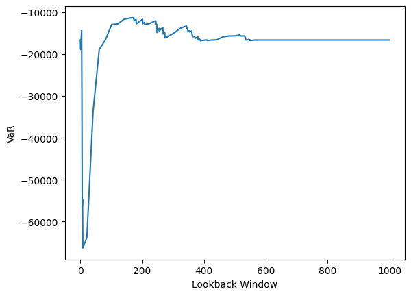

```python
N = 1000
VaRs = np.zeros((N, 1))
for i in range(N):
    VaRs[i] = value_at_risk(value_invested, returns, weights, lookback_days=i)

plt.plot(VaRs)
plt.xlabel('Lookback Window')
plt.ylabel('VaR');
```

Chúng ta có thể thấy rằng VaR có vẻ như hội tụ trong khoảng thời gian lookback từ 400-600 ngày. Do đó, tham số 520 ngày của chúng ta có vẻ ổn. Thực tế, 1000 ngày có thể tốt hơn vì nó sử dụng nhiều thông tin hơn, nhưng lại yêu cầu tính toán nhiều hơn và có thể gặp phải vấn đề về tính dừng.

Việc thực hiện các phân tích như thế này có thể rất hữu ích khi đánh giá liệu VaR có ý nghĩa hay không. Một kiểm tra khác mà chúng ta sẽ thực hiện là kiểm tra tính dừng của lợi suất danh mục đầu tư trong khoảng thời gian này.

```python
from statsmodels.tsa.stattools import adfuller

results = adfuller(portfolio_returns)
pvalue = results[1]

if pvalue < 0.05:
    print('Process is likely stationary.')
else:
    print('Process is likely non-stationary.')
```

```
Process is likely stationary.
```

## Giá trị rủi ro điều kiện (CVaR)

CVaR là điều mà nhiều người coi là một cải tiến so với VaR, vì nó xem xét hình dạng của phân phối lợi nhuận. Nó cũng được biết đến với tên gọi là Thiếu hụt kỳ vọng (ES), vì nó là một kỳ vọng về tất cả các khoản lỗ có thể xảy ra lớn hơn VaR và xác suất ước lượng tương ứng của chúng.

Nếu bạn chưa quen với các kỳ vọng, có rất nhiều nội dung có sẵn trực tuyến. Tuy nhiên, chúng tôi sẽ cung cấp một cái nhìn tổng quan ngắn gọn.

### Giá trị kỳ vọng

Giả sử bạn có một con xúc xắc đều sáu mặt. Mỗi số đều có xác suất như nhau. Khái niệm về một kỳ vọng, được viết là $\mathrm{E}(X)$, là điều bạn nên mong đợi sẽ xảy ra từ tất cả các kết quả có thể. Để có được điều này, bạn nhân mỗi sự kiện với xác suất của sự kiện đó và cộng chúng lại, hãy coi đó như một trung bình có trọng số xác suất. Với một con xúc xắc, chúng ta có:

$$1/6 \times 1 + 1/6 \times 2 + 1/6 \times 3 + 1/6 \times 4 + 1/6 \times 5 + 1/6 \times 6 = 3.5$$

Khi các xác suất không bằng nhau, nó trở nên phức tạp hơn, và khi các kết quả là liên tục, chúng ta phải sử dụng tích phân trong các phương trình dạng đóng. Đây là công thức cho CVaR.

$$CVaR_{\alpha}(x) \approx \frac{1}{(1-\alpha)} \int_{f(x,y) \geq VaR_{\alpha}(x)} f(x,y)p(y)dy dx$$

```python
def cvar(value_invested, returns, weights, alpha=0.95, lookback_days=520):
    # Call out to our existing function
    var = value_at_risk(value_invested, returns, weights, alpha, lookback_days=lookback_days)
    returns = returns.fillna(0.0)
    portfolio_returns = returns.iloc[-lookback_days:].dot(weights)

    # Get back to a return rather than an absolute loss
    var_pct_loss = var / value_invested

    return value_invested * np.nanmean(portfolio_returns[portfolio_returns < var_pct_loss])
```

Hãy tính toán CVaR trên dữ liệu của chúng ta và xem nó so sánh như thế nào với VaR.

```python
cvar(value_invested, returns, weights, lookback_days=500)
```

```
np.float64(-28346.464925808585)
```

```python
value_at_risk(value_invested, returns, weights, lookback_days=500)
```

```
np.float64(-15641.91969697943)
```

CVaR cao hơn vì nó nắm bắt nhiều thông tin hơn về hình dạng của phân phối, tức là các khoảng của phân phối. Nếu các đuôi có khối lượng lớn hơn, điều này sẽ được phản ánh. Nói chung, nó được coi là một chỉ số vượt trội hơn nhiều so với VaR và bạn nên sử dụng nó thay vì VaR trong hầu hết các trường hợp.

Hãy cùng hình dung những gì nó đang nắm bắt.

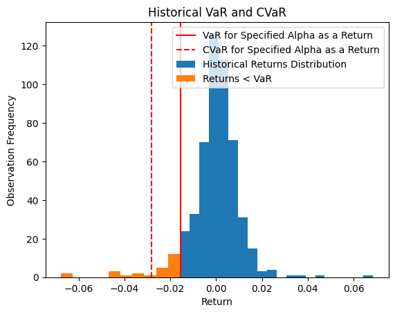

```python
lookback_days = 520
alpha = 0.95

# Multiply asset returns by weights to get one weighted portfolio return
portfolio_returns = returns.fillna(0.0).iloc[-lookback_days:].dot(weights)

portfolio_VaR = value_at_risk(value_invested, returns, weights, alpha=0.95)
# Need to express it as a return rather than absolute loss
portfolio_VaR_return = portfolio_VaR / value_invested

portfolio_CVaR = cvar(value_invested, returns, weights, alpha=0.95)
# Need to express it as a return rather than absolute loss
portfolio_CVaR_return = portfolio_CVaR / value_invested

# Plot only the observations > VaR on the main histogram so the plot comes out
# nicely and doesn't overlap.
plt.hist(portfolio_returns[portfolio_returns > portfolio_VaR_return], bins=20)
plt.hist(portfolio_returns[portfolio_returns < portfolio_VaR_return], bins=10)
plt.axvline(portfolio_VaR_return, color='red', linestyle='solid');
plt.axvline(portfolio_CVaR_return, color='red', linestyle='dashed');
plt.legend(['VaR for Specified Alpha as a Return',
            'CVaR for Specified Alpha as a Return',
            'Historical Returns Distribution',
            'Returns < VaR'])
plt.title('Historical VaR and CVaR');
plt.xlabel('Return');
plt.ylabel('Observation Frequency');
```

### Kiểm Tra Sự Hội Tụ Một Lần Nữa

Cuối cùng, chúng ta sẽ kiểm tra sự hội tụ.

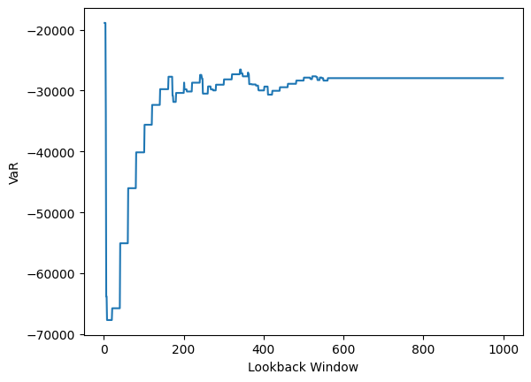

```python
N = 1000
CVaRs = np.zeros((N, 1))
for i in range(N):
    CVaRs[i] = cvar(value_invested, returns, weights, lookback_days=i)

plt.plot(CVaRs)
plt.xlabel('Lookback Window')
plt.ylabel('VaR');
```

## Nguồn tham khảo

- http://www.wiley.com/WileyCDA/WileyTitle/productCd-1118445597.html
- http://www.ise.ufl.edu/uryasev/publications/
- http://www.ise.ufl.edu/uryasev/files/2011/11/VaR_vs_CVaR_CARISMA_conference_2010.pdf
- http://faculty.washington.edu/ezivot/econ589/me20-1-4.pdf

*Lưu ý: Tài liệu này mang tính chất chia sẻ kiến thức khoa học dữ liệu. Các mã chứng khoán xuất hiện trong tài liệu chỉ mang tính chất minh hoạ, không khuyến nghị đầu tư. Chúng tôi không chịu trách nhiệm trước mọi rủi ro nào do sử dụng tài liệu này.*